# Support Vector Machine

- A Support Vector Machine (SVM) is a very powerful and versatile Machine Learning model, capable of performing linear or nonlinear classification, regression, and even outlier detection. It is one of the most popular models in Machine Learning, and anyone interested in Machine Learning should have it in their toolbox. SVMs are particularly well suited for classification of complex but small- or medium-sized datasets.

### SVM Classifier:

- This is called large margin classification. We can think of an SVM classifier as fitting the widest possible street (margin - represented by the parallel dashed lines) between the classes.

[figure not shown]

- Support Vectors : The closes data points to the decision boundary (optimal hyperplan) are know as Support Vectors (instances located at the edge of the street are know as support vectors).
- **SVM is very sensitive, please see below example for reference.**

[figure not shown]

### Soft Margin vs Hard Margin - classifier

- **Hard Margin classifier :** If we strictly impose that all instances be off the margin (street) and on the right side, this is called hard margin classification.
  - There are two main issues with hard margin classification.
    - First, it only works if the data is linearly separable.

[figure not shown]

    - Second it is quite sensitive to outliers.
- **Soft Margin classifier :** A more flexible model, the objective is to find a **balance between keeping the margin (street) as large as possible and limiting the margine violations.** ((i.e., instances that end up in the middle of the street **or** even on the wrong side).
  - The balance between **"margin size"** and **"margine violation"** can be controled using **"C"** Hyperparameter.
    - A **high C value** the classifier makes **fewer margin violations but ends up with a smaller margin.**
    - A **low C value** will **generalize better** with a **much larger margin**. In below example image, many instances end up on the margin (street) with most of the margin violations are actually on the correct side of the decision boundary. This makes the model make fewer prediction errors.

[figure not shown]

### More on SVM Support Vector Machine

## LinearSVC

```python
import pandas as pd
import numpy as np
import matplotlib.pyplot as plt
% matplotlib inline
import seaborn as sns
from sklearn.base import BaseEstimator, TransformerMixin
from sklearn.pipeline import Pipeline
from sklearn.preprocessing import StandardScaler
from sklearn.model_selection import GridSearchCV

plt.rcParams['axes.labelsize'] = 14
plt.rcParams['xtick.labelsize'] = 12
plt.rcParams['ytick.labelsize'] = 12
import warnings
warnings.filterwarnings('ignore')

import random
random.seed(10)
```

```python
iris_data =  pd.read_csv('../data/Iris.csv')
```

```python
iris_data.shape
```

```
(150, 6)
```

```python
iris_data.columns
```

```
Index(['Id', 'SepalLengthCm', 'SepalWidthCm', 'PetalLengthCm', 'PetalWidthCm',
       'Species'],
      dtype='object')
```

[figure not shown]

```python
iris_data.Species.value_counts()
```

```
Iris-setosa        50
Iris-versicolor    50
Iris-virginica     50
Name: Species, dtype: int64
```

```python
X = iris_data[['Id', 'SepalLengthCm', 'SepalWidthCm', 'PetalLengthCm', 'PetalWidthCm']]
y = iris_data['Species']
```

```python
from sklearn.model_selection import train_test_split
X_train, X_test, y_train, y_test = train_test_split(X, y, test_size=0.33, random_state=42)
```

### LinearSVC is not a multi-class classifier, hence Scikit-Learn applies One-Vs-Rest and derives prediction for the multi class problem

```python
from sklearn.svm import LinearSVC

svm_clf = Pipeline([ ("scaler", StandardScaler()),
                    ("linear_svc", LinearSVC( C = 1, loss ="hinge")) ])
svm_clf.fit( X_train, y_train)
```

```
Pipeline(steps=[(' scaler', StandardScaler(copy=True, with_mean=True, with_std=True)), (' linear_svc', LinearSVC(C=1, class_weight=None, dual=True, fit_intercept=True,
     intercept_scaling=1, loss='hinge', max_iter=1000, multi_class='ovr',
     penalty='l2', random_state=None, tol=0.0001, verbose=0))])
```

```python
svm_clf.classes_
```

```
array(['Iris-setosa', 'Iris-versicolor', 'Iris-virginica'], dtype=object)
```

```python
y_train_pred = svm_clf.predict(X_train)
```

```python
from sklearn.metrics import confusion_matrix
confusion_matrix(y_train, y_train_pred)
```

```
array([[30,  1,  0],
       [ 0, 35,  0],
       [ 0,  1, 33]])
```

```python
from sklearn.metrics import precision_score, recall_score
print("Precision Score : ", precision_score(y_train, y_train_pred, average="macro"))
print("Recall Score : ", recall_score(y_train, y_train_pred, average="macro"))
```

```
Precision Score :  0.981981981982
Recall Score :  0.979443390259
```

### Test model on Test Set

```python
y_test_pred = svm_clf.predict(X_test)
print("Test - Confusion Matrix \n ", confusion_matrix(y_test, y_test_pred))
print("Test - Precision ", precision_score(y_test, y_test_pred, average="macro"))
print("Test - Recall ", recall_score(y_test, y_test_pred, average="macro"))
```

```
Test - Confusion Matrix
  [[19  0  0]
 [ 1 14  0]
 [ 0  1 15]]
Test - Precision  0.961111111111
Test - Recall  0.956944444444
```

### How to decide threshold (Decision Score) in a multi-class classification.

```python
y_decision_score = svm_clf.decision_function(X_train)
```

```python
y_decision_score.shape
```

```
(100, 3)
```

```python
y_decision_score[:5, :]
```

```
array([[-1.3611845 , -0.73750953, -1.04526128],
       [-3.73993763,  0.39279372,  1.45855839],
       [-1.23737519,  0.20868921, -1.68486285],
       [ 2.99533849, -1.08103947, -8.26419174],
       [-4.17893177,  0.51298242,  2.08509888]])
```

```python
def plot_precision_recall_curve(precisions, recalls, thresholds):
    plt.plot(thresholds, precisions[:-1], "b--", label="Precision", linewidth=2)
    plt.plot(thresholds, recalls[:-1], "g-", label="Recall", linewidth=2)
    plt.xlabel("Decision Score", fontsize=16)
    plt.legend(loc="center right", fontsize=16)
    plt.xlim([np.min(thresholds), np.max(thresholds)])
    plt.ylim([0, 1])
    plt.xticks(rotation=90)
```

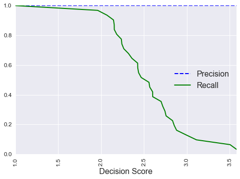

```python
from sklearn.metrics import precision_recall_curve
precisions, recalls, thresholds = precision_recall_curve(y_train, y_decision_score[:, 0], pos_label=['Iris-setosa'])
plot_precision_recall_curve(precisions, recalls, thresholds)
```

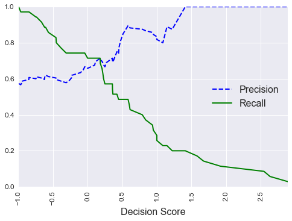

```python
precisions, recalls, thresholds = precision_recall_curve(y_train, y_decision_score[:, 1], pos_label=['Iris-versicolor'])
plot_precision_recall_curve(precisions, recalls, thresholds)
```

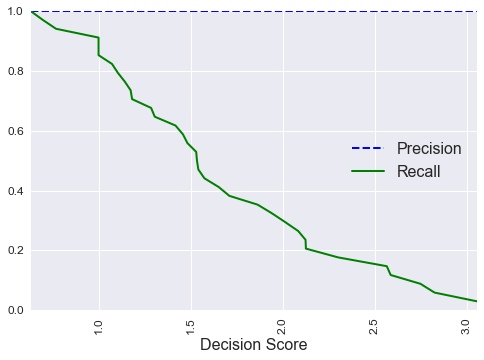

```python
precisions, recalls, thresholds = precision_recall_curve(y_train, y_decision_score[:, 2], pos_label=['Iris-virginica'])
plot_precision_recall_curve(precisions, recalls, thresholds)
```

**Note :** An alternative for "LinearSVC" is "SVC" class from sklearn.svm, using SVC( kernel ="linear", C = 1), but it is much slower, especially with large training sets, so it is not recommended.

## Non-Linear SVM Classification

### Two ways to handles this

#### 1) Add polynomial features, use LinearSVC

#### 2) Going with Kernal approach.

#### 1) Add polynomial features, use LinearSVC

- When data is not linearly separable, we could add more polynomial features, some times this will make data linearly separable. If we see below example with one feature $x_1$, the data is not linearly separable. Once after adding $x_2 = x_{1}^2$, the data is linearly separable.

[figure not shown]

- To implement this idea using Scikit-Learn, you can create a Pipeline containing a PolynomialFeatures transformer (discussed in “Polynomial Regression”), followed by a StandardScaler and a LinearSVC.

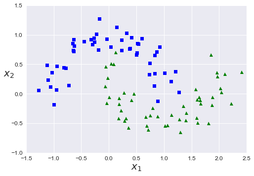

```python
from sklearn.datasets import make_moons
X, y = make_moons(n_samples=100, noise=0.15, random_state=42)

def plot_dataset(X, y, axes):
    plt.plot(X[:, 0][y==0], X[:, 1][y==0], "bs")
    plt.plot(X[:, 0][y==1], X[:, 1][y==1], "g^")
    plt.axis(axes)
    plt.grid(True, which='both')
    plt.xlabel(r"$x_1$", fontsize=20)
    plt.ylabel(r"$x_2$", fontsize=20, rotation=0)

plot_dataset(X, y, [-1.5, 2.5, -1, 1.5])
plt.show()
```

```python
ls =LinearSVC()
ls.get_params().keys()
```

```
dict_keys(['C', 'class_weight', 'dual', 'fit_intercept', 'intercept_scaling', 'loss', 'max_iter', 'multi_class', 'penalty', 'random_state', 'tol', 'verbose'])
```

```python
from sklearn.preprocessing import PolynomialFeatures
from sklearn.model_selection import RandomizedSearchCV
from sklearn.model_selection import GridSearchCV

polynomial_svm_clf = Pipeline([
        ("poly_features", PolynomialFeatures()),
        ("scaler", StandardScaler()),
        ("svm_clf", LinearSVC(random_state=42))
    ])

param_grid = param_grid = {
        "poly_features__degree": np.arange(1,20),
        "svm_clf__C": np.arange(1, 10)
    }
```

#### Comparision between RandomizedSearchCV and GridSearchCV

```python
def plot_predictions(clf, axes):
    x0s = np.linspace(axes[0], axes[1], 100)
    x1s = np.linspace(axes[2], axes[3], 100)
    x0, x1 = np.meshgrid(x0s, x1s)
    X = np.c_[x0.ravel(), x1.ravel()]
    y_pred = clf.predict(X).reshape(x0.shape)
    y_decision = clf.decision_function(X).reshape(x0.shape)
    plt.contourf(x0, x1, y_pred, cmap=plt.cm.brg, alpha=0.2)
    plt.contourf(x0, x1, y_decision, cmap=plt.cm.brg, alpha=0.1)
```

```python
polynomial_random_svn = RandomizedSearchCV(polynomial_svm_clf, param_grid, cv=10, random_state=20)
polynomial_random_svn.fit(X, y)
print("Best params : ", polynomial_random_svn.best_params_)
print("Best estimator : ", polynomial_random_svn.best_estimator_)
```

```
Best params :  {'svm_clf__C': 1, 'poly_features__degree': 16}
Best estimator :  Pipeline(steps=[('poly_features', PolynomialFeatures(degree=16, include_bias=True, interaction_only=False)), ('scaler', StandardScaler(copy=True, with_mean=True, with_std=True)), ('svm_clf', LinearSVC(C=1, class_weight=None, dual=True, fit_intercept=True,
     intercept_scaling=1, loss='squared_hinge', max_iter=1000,
     multi_class='ovr', penalty='l2', random_state=42, tol=0.0001,
     verbose=0))])
```

#### Outcome of RandomizedSearchCV is kind of overfitting.

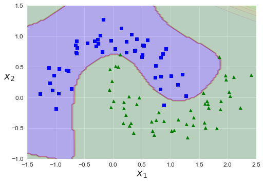

```python
polynomial_svm_clf_1 = Pipeline([
        ("poly_features", PolynomialFeatures(degree=16)),
        ("scaler", StandardScaler()),
        ("svm_clf", LinearSVC(C=1, random_state=42))
    ])
polynomial_svm_clf_1.fit(X, y)
plot_predictions(polynomial_svm_clf_1, [-1.5, 2.5, -1, 1.5])
plot_dataset(X, y, [-1.5, 2.5, -1, 1.5])
plt.show()
```

```python
polynomial_grid_search_svn = GridSearchCV(polynomial_svm_clf, param_grid, cv=10)
polynomial_grid_search_svn.fit(X, y)
print("Best params : ", polynomial_grid_search_svn.best_params_)
print("Best estimator : ", polynomial_grid_search_svn.best_estimator_)
```

```
Best params :  {'poly_features__degree': 3, 'svm_clf__C': 2}
Best estimator :  Pipeline(steps=[('poly_features', PolynomialFeatures(degree=3, include_bias=True, interaction_only=False)), ('scaler', StandardScaler(copy=True, with_mean=True, with_std=True)), ('svm_clf', LinearSVC(C=2, class_weight=None, dual=True, fit_intercept=True,
     intercept_scaling=1, loss='squared_hinge', max_iter=1000,
     multi_class='ovr', penalty='l2', random_state=42, tol=0.0001,
     verbose=0))])
```

#### Outcome of GridSearchCV looks reasonable but took lot of time to execute.

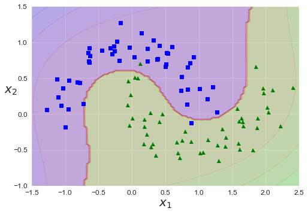

```python
polynomial_svm_clf_2 = Pipeline([
        ("poly_features", PolynomialFeatures(degree=3)),
        ("scaler", StandardScaler()),
        ("svm_clf", LinearSVC(C=2, random_state=42))
    ])
polynomial_svm_clf_2.fit(X, y)
plot_predictions(polynomial_svm_clf_2, [-1.5, 2.5, -1, 1.5])
plot_dataset(X, y, [-1.5, 2.5, -1, 1.5])
plt.show()
```

- **Problems with adding polynomial features : ** is simple to implement and can work great with all sorts of Machine Learning algorithms (not just SVMs), but at a low polynomial degree it cannot deal with very complex datasets, and with a high polynomial degree it creates a huge number of features, making the model too slow.

#### 2) Kernel Approach

- With SVM, we can apply Kernel trick, the trick makes it possible to get the same result with out adding many polynomial features. This will solve the problem of combinatorial explosion of the number of features.

### More on Kernel SVM

```python
from sklearn.svm import SVC
poly_svc_clf = Pipeline([
        ("scaler", StandardScaler()),
        ("svc_clf", SVC(kernel='poly'))
    ])

param_grid_svc = param_grid = {
        "svc_clf__degree": np.arange(1, 10),
        "svc_clf__C": np.arange(1, 10),
        "svc_clf__coef0": np.arange(1, 10)
    }
```

##### coef0 : The Hyperparameter "coef0" can be used to reduce "Overfitting" of a high degree polynomial. This is kind of regularization (shrinkage) parameter in Linear Models.

```python
poly_grid_search_svc = GridSearchCV(poly_svc_clf, param_grid_svc, cv=10)
poly_grid_search_svc.fit(X, y)
print("Best params : ", poly_grid_search_svc.best_params_)
print("Best estimator : ", poly_grid_search_svc.best_estimator_)
```

```
Best params :  {'svc_clf__C': 1, 'svc_clf__coef0': 9, 'svc_clf__degree': 4}
Best estimator :  Pipeline(steps=[('scaler', StandardScaler(copy=True, with_mean=True, with_std=True)), ('svc_clf', SVC(C=1, cache_size=200, class_weight=None, coef0=9,
  decision_function_shape=None, degree=4, gamma='auto', kernel='poly',
  max_iter=-1, probability=False, random_state=None, shrinking=True,
  tol=0.001, verbose=False))])
```

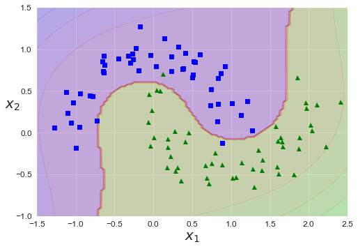

```python
best_poly_svc_clf = Pipeline([
        ("scaler", StandardScaler()),
        ("svc_clf", SVC(kernel='poly', degree=4, C=1, coef0=9))
    ])
poly_grid_search_svc.fit(X, y)
plot_predictions(polynomial_svm_clf_2, [-1.5, 2.5, -1, 1.5])
plot_dataset(X, y, [-1.5, 2.5, -1, 1.5])
plt.show()
```

## Support Vector Regression

- Where $x_{i}$ is a training sample with target value $y_{i}$. The inner product plus intercept $ W^{T} * X_{i} +b $ is the **prediction** for that sample
- The trick is to reverse the objective: instead of trying to fit the largest possible street between two classes while limiting margin violations, SVM Regression tries to fit as many instances as possible on the street while limiting margin violations (i.e., instances off the street). The width of the street is controlled by a hyperparameter ϵ.
- Training the original SVR means solving[27]
  - $ minimize {\displaystyle {\frac {1}{2}}\|w\|^{2}}$ Subject to ${\displaystyle {\begin{cases}y_{i}-\langle w,x_{i}\rangle -b\leq \varepsilon \\\langle w,x_{i}\rangle +b-y_{i}\leq \varepsilon \end{cases}}} $
- $\epsilon$ is a free parameter that serves as a threshold: all predictions have to be within an $\varepsilon$ range of the true predictions.

[figure not shown]